# Tutorial 3 - SVM

## Week 3 : SVM Classifier

In this tutorial, we will use a smaller version of the MNIST Digit dataset and perform classification of the digits using SVM Classifier

#### Import Packages

```python
import numpy as np
import pandas as pd
import matplotlib.pyplot as plt
import seaborn as sns
from sklearn.svm import SVC
from sklearn.metrics import accuracy_score
from sklearn.model_selection import train_test_split
```

#### Load data

```python
data = pd.read_csv('mnist_digits.csv')
print("Dimensions:", data.shape)
data.head()
```

```
Dimensions: (1800, 785)
```

|  | label | pixel0 | pixel1 | pixel2 | pixel3 | pixel4 | pixel5 | pixel6 | pixel7 | pixel8 | ... | pixel774 | pixel775 | pixel776 | pixel777 | pixel778 | pixel779 | pixel780 | pixel781 | pixel782 | pixel783 |
| --- | --- | --- | --- | --- | --- | --- | --- | --- | --- | --- | --- | --- | --- | --- | --- | --- | --- | --- | --- | --- | --- |
| 0 | 0 | 0 | 0 | 0 | 0 | 0 | 0 | 0 | 0 | 0 | ... | 0 | 0 | 0 | 0 | 0 | 0 | 0 | 0 | 0 | 0 |
| 1 | 1 | 0 | 0 | 0 | 0 | 0 | 0 | 0 | 0 | 0 | ... | 0 | 0 | 0 | 0 | 0 | 0 | 0 | 0 | 0 | 0 |
| 2 | 2 | 0 | 0 | 0 | 0 | 0 | 0 | 0 | 0 | 0 | ... | 0 | 0 | 0 | 0 | 0 | 0 | 0 | 0 | 0 | 0 |
| 3 | 3 | 0 | 0 | 0 | 0 | 0 | 0 | 0 | 0 | 0 | ... | 0 | 0 | 0 | 0 | 0 | 0 | 0 | 0 | 0 | 0 |
| 4 | 4 | 0 | 0 | 0 | 0 | 0 | 0 | 0 | 0 | 0 | ... | 0 | 0 | 0 | 0 | 0 | 0 | 0 | 0 | 0 | 0 |

5 rows × 785 columns

```python
target = data.pop('label')
target.head(10)
```

```
0    0
1    1
2    2
3    3
4    4
5    5
6    6
7    7
8    8
9    9
Name: label, dtype: int64
```

#### Understanding the data

```python
# Each observation contains values of the pixels arranged as 28*28, print the first observation gives the following result:

# Reshape the observation into matrix first and then print
for row in data.loc[0].values.reshape(28,28):
    print(' '.join('{:3}'.format(value) for value in row))
```

```
  0   0   0   0   0   0   0   0   0   0   0   0   0   0   0   0   0   0   0   0   0   0   0   0   0   0   0   0
  0   0   0   0   0   0   0   0   0   0   0   0   0   0   0   0   0   0   0   0   0   0   0   0   0   0   0   0
  0   0   0   0   0   0   0   0   0   0   0   0   0   0   0   0   0   0   0   0   0   0   0   0   0   0   0   0
  0   0   0   0   0   0   0   0   0   0   0   0   0   0   0   0   0   0   0   0   0   0   0   0   0   0   0   0
  0   0   0   0   0   0   0   0   0   0   0   0   0   0   0   0   0   0   0   0   0   0   0   0   0   0   0   0
  0   0   0   0   0   0   0   0   0   0   0   0   0   0   0   0   0   0   0   0   0   0   0   0   0   0   0   0
  0   0   0   0   0   0   0   0   0   0   0   0   0   0   0  52 235 241 241 135 108 108  40   0   0   0   0   0
  0   0   0   0   0   0   0   0   0   0   0   0   0   5  94 241 253 253 253 253 253 253 237 145   0   0   0   0
  0   0   0   0   0   0   0   0   0   0   0  13  95 216 253 254 253 223 173 173 190 253 253 240   0   0   0   0
  0   0   0   0   0   0   0   0   0   0  50  97 253 253 253 254 253 173  21   0  12  85 253 250 165   0   0   0
  0   0   0   0   0   0   0   0   0  50 236 253 253 253 253 254 145   7   0   0   0  32 234 253 147   0   0   0
  0   0   0   0   0   0   0   0  77 195 253 253 253 223  80  80   4   0   0   0   0  28 224 253 161   0   0   0
  0   0   0   0   0   0   0  10 218 253 253 235 141  39   0   0   0   0   0   0   0  55 253 252 107   0   0   0
  0   0   0   0   0   0   6 173 253 253 250  75   0   0   0   0   0   0   0   0  32 220 253 240   0   0   0   0
  0   0   0   0   0   0 108 253 253 253 128   0   0   0   0   0   0   0   0   0  54 253 253 240   0   0   0   0
  0   0   0   0   0   0 171 254 254 187   0   0   0   0   0   0   0   0   0  32 220 255 255 177   0   0   0   0
  0   0   0   0   0  52 175 253 219 143  35   0   0   0   0   0   0   0   0 124 253 253 185  62   0   0   0   0
  0   0   0   0   0 121 253 253 103   0   0   0   0   0   0   0   0   0 193 248 253 253 142   0   0   0   0   0
  0   0   0   0   0 234 253 253  60   0   0   0   0   0   0   0 133 214 247 253 236  81  35   0   0   0   0   0
  0   0   0   0   0 183 253 253 110   0   0   0   0   4  68 202 251 253 253 200 147   0   0   0   0   0   0   0
  0   0   0   0   0 254 253 253 197  82  54 145 187 191 253 254 253 233 157  14   0   0   0   0   0   0   0   0
  0   0   0   0   0 143 251 253 253 253 253 253 253 253 253 255 158  50   0   0   0   0   0   0   0   0   0   0
  0   0   0   0   0   0 145 236 253 253 253 235 226 219  93  94   5   0   0   0   0   0   0   0   0   0   0   0
  0   0   0   0   0   0   0  40 107 107 107  34   0   0   0   0   0   0   0   0   0   0   0   0   0   0   0   0
  0   0   0   0   0   0   0   0   0   0   0   0   0   0   0   0   0   0   0   0   0   0   0   0   0   0   0   0
  0   0   0   0   0   0   0   0   0   0   0   0   0   0   0   0   0   0   0   0   0   0   0   0   0   0   0   0
  0   0   0   0   0   0   0   0   0   0   0   0   0   0   0   0   0   0   0   0   0   0   0   0   0   0   0   0
  0   0   0   0   0   0   0   0   0   0   0   0   0   0   0   0   0   0   0   0   0   0   0   0   0   0   0   0
```

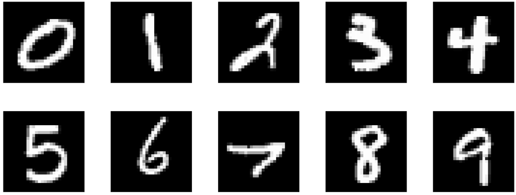

```python
def plot_gallery(images, h, w, n_row=2, n_col=5):
    """Helper function to plot a gallery of portraits"""
    plt.figure(figsize=(5 * n_col, 5 * n_row))
    plt.subplots_adjust(bottom=0, left=.01, right=.99, top=.90, hspace=.35)
    for i in range(n_row * n_col):
        plt.subplot(n_row, n_col, i + 1)
        plt.imshow(images[i].reshape((h, w)), cmap=plt.cm.gray)
        plt.xticks(())
        plt.yticks(())

# Reshaping the pixel value to images
# plotting the first 10 observations -
plot_gallery(data.loc[range(10)].values.reshape(10, 28,28), 28, 28)
```

#### Basic checks before we move onto modelling :-

```python
data.isnull().sum().sum()
```

```
0
```

There are no missing values in this dataset.

```python
data.describe()
```

|  | pixel0 | pixel1 | pixel2 | pixel3 | pixel4 | pixel5 | pixel6 | pixel7 | pixel8 | pixel9 | ... | pixel774 | pixel775 | pixel776 | pixel777 | pixel778 | pixel779 | pixel780 | pixel781 | pixel782 | pixel783 |
| --- | --- | --- | --- | --- | --- | --- | --- | --- | --- | --- | --- | --- | --- | --- | --- | --- | --- | --- | --- | --- | --- |
| count | 1800.0 | 1800.0 | 1800.0 | 1800.0 | 1800.0 | 1800.0 | 1800.0 | 1800.0 | 1800.0 | 1800.0 | ... | 1800.000000 | 1800.0 | 1800.0 | 1800.0 | 1800.0 | 1800.0 | 1800.0 | 1800.0 | 1800.0 | 1800.0 |
| mean | 0.0 | 0.0 | 0.0 | 0.0 | 0.0 | 0.0 | 0.0 | 0.0 | 0.0 | 0.0 | ... | 0.057778 | 0.0 | 0.0 | 0.0 | 0.0 | 0.0 | 0.0 | 0.0 | 0.0 | 0.0 |
| std | 0.0 | 0.0 | 0.0 | 0.0 | 0.0 | 0.0 | 0.0 | 0.0 | 0.0 | 0.0 | ... | 2.034990 | 0.0 | 0.0 | 0.0 | 0.0 | 0.0 | 0.0 | 0.0 | 0.0 | 0.0 |
| min | 0.0 | 0.0 | 0.0 | 0.0 | 0.0 | 0.0 | 0.0 | 0.0 | 0.0 | 0.0 | ... | 0.000000 | 0.0 | 0.0 | 0.0 | 0.0 | 0.0 | 0.0 | 0.0 | 0.0 | 0.0 |
| 25% | 0.0 | 0.0 | 0.0 | 0.0 | 0.0 | 0.0 | 0.0 | 0.0 | 0.0 | 0.0 | ... | 0.000000 | 0.0 | 0.0 | 0.0 | 0.0 | 0.0 | 0.0 | 0.0 | 0.0 | 0.0 |
| 50% | 0.0 | 0.0 | 0.0 | 0.0 | 0.0 | 0.0 | 0.0 | 0.0 | 0.0 | 0.0 | ... | 0.000000 | 0.0 | 0.0 | 0.0 | 0.0 | 0.0 | 0.0 | 0.0 | 0.0 | 0.0 |
| 75% | 0.0 | 0.0 | 0.0 | 0.0 | 0.0 | 0.0 | 0.0 | 0.0 | 0.0 | 0.0 | ... | 0.000000 | 0.0 | 0.0 | 0.0 | 0.0 | 0.0 | 0.0 | 0.0 | 0.0 | 0.0 |
| max | 0.0 | 0.0 | 0.0 | 0.0 | 0.0 | 0.0 | 0.0 | 0.0 | 0.0 | 0.0 | ... | 84.000000 | 0.0 | 0.0 | 0.0 | 0.0 | 0.0 | 0.0 | 0.0 | 0.0 | 0.0 |

8 rows × 784 columns

You can see that the max value of the max value of pixel774 is 84, whereas most features lie in much lower ranges (look at description of pixel 0, pixel 1 etc. above).

Thus, it seems like a good idea to rescale the features.

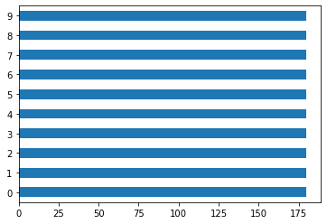

```python
target.value_counts().plot(kind='barh')
```

The dataset contains equal observations for all the classes of digits.

#### Split into a training and testing set

```python
X_train, X_test, y_train, y_test = train_test_split(data, target, test_size=0.25, random_state=42)
```

```python
from sklearn.preprocessing import StandardScaler
scaler = StandardScaler().fit(X_train)
X_train_scaled = scaler.transform(X_train)
X_test_scaled = scaler.transform(X_test)
```

### SVM Classifier

Support vector machines are known to solve linear and non-linear problems. The idea of SVM is to create a hyperplane that divides the data into different classes. Read the [documentation](https://scikit-learn.org/stable/modules/generated/sklearn.svm.SVC.html#sklearn.svm.SVC) for more information. Details of the scikit learn SVM Classifier can be found [here](https://scikit-learn.org/stable/modules/generated/sklearn.svm.SVC.html#sklearn.svm.SVC)

#### Task 1:

Fit SVC with a **linear kernel** on the traning data and check the accuracy on the testing data

#### Task 2:

Fit SVC with a **radial kernel** on the traning data and check the accuracy on the testing data

#### Task 3:

Fit SVC with a **polynomial kernel** on the traning data and check the accuracy on the testing data. Also check if degree of the polynomial improves/aggravates the predictions

#### Task 4:

Fit SVC with a **sigmoid kernel** on the traning data and check the accuracy on the testing data

### Exercise:

Load the dataset - *smartphone_based_human_activities.csv* and perform classification of the activities using SVM. Report which kernel performs the best on this dataset and why do you think so?

**Note:** The data may have to be preprocessed before using it for modelling. Explore the different hyperparameters of the SVM classifier. Compare the performance of the classifiers with same kernel type but one with soft margin and another with hard margin.

The **dataset description** is given below:

The experiments have been carried out with a group of 30 volunteers within an age bracket of 19-48 years. Each person performed six activities (WALKING, WALKING_UPSTAIRS, WALKING_DOWNSTAIRS, SITTING, STANDING, LAYING) wearing a smartphone (Samsung Galaxy S II) on the waist. Using its embedded accelerometer and gyroscope, we captured 3-axial linear acceleration and 3-axial angular velocity at a constant rate of 50Hz. The experiments have been video-recorded to label the data manually.

The sensor signals (accelerometer and gyroscope) were pre-processed by applying noise filters and then sampled in fixed-width sliding windows of 2.56 sec and 50% overlap (128 readings/window). The sensor acceleration signal, which has gravitational and body motion components, was separated using a Butterworth low-pass filter into body acceleration and gravity. The gravitational force is assumed to have only low frequency components, therefore a filter with 0.3 Hz cutoff frequency was used. From each window, a vector of features was obtained by calculating variables from the time and frequency domain.

The **features selected for this dataset** come from the accelerometer and gyroscope 3-axial raw signals tAcc-XYZ and tGyro-XYZ. These time domain signals (prefix 't' to denote time) were captured at a constant rate of 50 Hz. Then they were filtered using a median filter and a 3rd order low pass Butterworth filter with a corner frequency of 20 Hz to remove noise. Similarly, the acceleration signal was then separated into body and gravity acceleration signals (tBodyAcc-XYZ and tGravityAcc-XYZ) using another low pass Butterworth filter with a corner frequency of 0.3 Hz.

Subsequently, the body linear acceleration and angular velocity were derived in time to obtain Jerk signals (tBodyAccJerk-XYZ and tBodyGyroJerk-XYZ). Also the magnitude of these three-dimensional signals were calculated using the Euclidean norm (tBodyAccMag, tGravityAccMag, tBodyAccJerkMag, tBodyGyroMag, tBodyGyroJerkMag).

Finally a Fast Fourier Transform (FFT) was applied to some of these signals producing fBodyAcc-XYZ, fBodyAccJerk-XYZ, fBodyGyro-XYZ, fBodyAccJerkMag, fBodyGyroMag, fBodyGyroJerkMag. (Note the 'f' to indicate frequency domain signals).

These signals were used to estimate variables of the feature vector for each pattern:  
'-XYZ' is used to denote 3-axial signals in the X, Y and Z directions.

tBodyAcc-XYZ  
tGravityAcc-XYZ  
tBodyAccJerk-XYZ  
tBodyGyro-XYZ  
tBodyGyroJerk-XYZ  
tBodyAccMag  
tGravityAccMag  
tBodyAccJerkMag  
tBodyGyroMag  
tBodyGyroJerkMag  
fBodyAcc-XYZ  
fBodyAccJerk-XYZ  
fBodyGyro-XYZ  
fBodyAccMag  
fBodyAccJerkMag  
fBodyGyroMag  
fBodyGyroJerkMag

The set of variables that were estimated from these signals are:

mean(): Mean value  
std(): Standard deviation  
mad(): Median absolute deviation  
max(): Largest value in array  
min(): Smallest value in array  
sma(): Signal magnitude area  
energy(): Energy measure. Sum of the squares divided by the number of values.  
iqr(): Interquartile range  
entropy(): Signal entropy  
arCoeff(): Autorregresion coefficients with Burg order equal to 4  
correlation(): correlation coefficient between two signals  
maxInds(): index of the frequency component with largest magnitude  
meanFreq(): Weighted average of the frequency components to obtain a mean frequency  
skewness(): skewness of the frequency domain signal  
kurtosis(): kurtosis of the frequency domain signal  
bandsEnergy(): Energy of a frequency interval within the 64 bins of the FFT of each window.  
angle(): Angle between to vectors.

Additional vectors obtained by averaging the signals in a signal window sample. These are used on the angle() variable:

gravityMean  
tBodyAccMean  
tBodyAccJerkMean  
tBodyGyroMean  
tBodyGyroJerkMean